# Integración de inteligencia artificial en la enseñanza de programación en R y análisis de datos en el nivel universitario

Módulo 1: Introducción y herramientas en la nube

Dra Teresa Boca

# ¿Qué es R?

[figure not shown]

## R: el lenguaje

- **R** es un entorno y lenguaje de programación para análisis y gráficos estadísticos.
- Es muy flexible: tiene una interfaz de línea de comandos.
- Existen miles de **librerías** creadas por usuarios de todo el mundo.
- En última instancia, podemos programar nuestros propios procedimientos.

[figure not shown]

## ¿Cómo se instala?

- **R**: se descarga desde el [CRAN](https://cran.r-project.org/index.html)(*Comprehensive R Archive Network*).
- actualizaciones frecuentes (cada ~3 meses).
- **RStudio**: se descarga desde posit.co y se instala con las opciones por defecto.
- La instalación básica de R (*core*) trae paquetes base: `base`, `graphics`, `stats`, `utils`

[figure not shown]

[figure not shown]

## Paquetes en R

- Los paquetes son conjuntos de funciones, datos y herramientas que amplían las capacidades de R.
- Se instalan una sola vez y se cargan cada vez que iniciamos una sesión de trabajo.
- Al cargar un paquete, sus funciones quedan disponibles para realizar nuestros análisis.
- En R, muchas veces se usa “librería” como sinónimo de paquete, aunque técnicamente no son exactamente lo mismo.

## Objetos en R

- Todo lo que creamos y utilizamos en R es un objeto. Cada objeto tiene un nombre, un contenido y características propias.
- Las características de un objeto determinan cómo podemos trabajar con él.
- R ofrece funciones para consultar estas características.

# Más allá de R: Quarto y Shiny

## ¿Qué es Quarto?

- **Quarto** es un sistema de publicación científica y técnica (de Posit, los creadores de RStudio).
- Permite combinar **texto**, **código** (R, Python, Julia, Observable) y sus **resultados** en un único documento.
- A partir de un mismo archivo `.qmd` se puede generar:
  - documentos (HTML, PDF, Word)
  - presentaciones (como esta, en reveal.js)
  - libros y sitios web
  - *dashboards*
  - [Pagina web quarto](https://quarto.org/)

[figure not shown]

## ¿Qué podemos hacer con Quarto?

- Reportes reproducibles: el análisis y el texto conviven en el mismo lugar, y se actualizan juntos si cambian los datos.
- Presentaciones interactivas para clases o congresos.
- Sitios web y blogs personales o de proyectos.
- Libros y manuales técnicos (como el material de este taller).
- *Dashboards* para comunicar resultados de forma visual

[figure not shown]

## ¿Qué podemos hacer con Shiny?

- **Shiny** es un paquete de R (y Python) para crear **aplicaciones web interactivas** sin necesidad de saber HTML, CSS o JavaScript
- Exploradores de datos interactivos (filtrar, graficar, elegir variables desde la web).
- *Dashboards* dinámicos para monitorear resultados o indicadores.
- Herramientas para que colegas sin conocimientos de R usen nuestros análisis desde el navegador.
- [Galeria de Shiny](https://shiny.posit.co/r/gallery/)

## Módulo 1: Introducción y herramientas en la nube

[figure not shown]

## Introducción y herramientas en la nube

[figure not shown]

## Temario

- **Conceptos básicos:**
  - Uso de modelos de lenguaje para la programación en R para no programadores.🙆‍♀️
- **Google Colab y Gemini:**
  - Configuración inicial mediante una cuenta de Gmail y Google Drive.
  - Instalación de librerías y extensiones necesarias para ejecutar R en un entorno nativo de Python.
- **Ejercicios prácticos**
  - Generación y análisis de datos
  - Generación de informes en formato editable

## Ventajas

1. No hay que instalar nada en la computadora del alumno.
2. Se ejecuta en la nube, funciona en cualquier equipo con navegador.
3. Es gratuito con una cuenta de Google.
4. Los notebooks se guardan solos en Google Drive y se pueden compartir como un documento.

## Google Colab

[Abrir Google Colab para crear un notebook de R](https://colab.research.google.com/#create=true&language=r)

1. Es necesario tener una cuenta de gmail
2. Abrir una carpeta en google drive y generar un archivo colab
3. Se abrirá automáticamente un notebook nuevo configurado para usar R (van a ver que dice “R” en el menú, no “Python 3”).

[figure not shown]

Captura de Google Colab

## Conocer la interfaz básica

Una vez abierto el notebook, mostrar estos elementos:

| Elemento | Qué es |
| --- | --- |
| **Celda de código** | Recuadro gris donde se escribe código R |
| **Celda de texto** | Recuadro para escribir explicaciones en Markdown (texto normal) |
| **Botón ▶ (Play)** | Ejecuta el contenido de la celda |
| **+ Código / + Texto** | Botones para agregar nuevas celdas |
| **Entorno de ejecución (Runtime)** | Menú para reiniciar o conectar el “motor” que ejecuta el código |

## Ejercicio 1.1: Primeros pasos con R — Pedirle a la AI

[figure not shown]

Captura de Google Colab

## Ejercicio 1.2: Operaciones básicas

Pedirle a la AI hacer una análisis descriptivo completo que incluya una tabla con todos los estadísticos descriptivos por tratamiento y un gráfico tipo bloxplot del archivos data generado.

[figure not shown]

Captura de Google Colab

## Ejercicio 1.3: Operaciones básicas

Guardar los datos generados.

[figure not shown]

Captura de Google Colab

## Ejercicio 1.4: Subir un archivo propio

Cuando quieran trabajar con datos propios, (vamos a subir los generados)

1. En el panel izquierdo, hacer clic en el ícono de carpeta (Archivos).
2. Hacer clic en el ícono de subir archivo (una hoja con una flecha hacia arriba).
3. Seleccionar el CSV desde la computadora. Quedará disponible en la ruta `/content/nombre_archivo.csv`.

## Ejercicio 1.5: Leerlo en R:

```r
mis_datos <- read.csv("/content/nombre_archivo.csv")
head(mis_datos)
```

**Nota:** los archivos subidos así se borran cuando se cierra la sesión. Si quieren que persistan, pueden conectar Google Drive (complicado que no vale la pena).

## Ejercicio 1.6: Guardar y compartir el trabajo

- El notebook se guarda automáticamente en Google Drive, en una carpeta llamada “Colab Notebooks”.
- Para compartir: botón **Compartir** (arriba a la derecha), igual que en Google Docs.
- Para descargar una copia: **Archivo → Descargar → Descargar .ipynb** (o como PDF si quieren que entreguen un informe).

## Ejercicio 2.1: Generar un informe para entregar

1. Entrá a https://colab.research.google.com y creá un notebook nuevo.
2. Andá al menú **Entorno de ejecución → Cambiar tipo de entorno de ejecución**.
3. En “Idioma del entorno de ejecución” elegí **R** (en vez de Python 3).
4. Guardá los cambios. El notebook ahora ejecuta código R directamente en cada celda.

## Ejercicio 2.2: Instalar lo necesario para renderizar R Markdown

En Colab con entorno R, `rmarkdown` suele venir preinstalado, pero conviene asegurarse. En una celda de código, ejecutá:

```r
# Verificar/instalar paquetes necesarios
if (!require("rmarkdown")) install.packages("rmarkdown")
if (!require("dplyr")) install.packages("dplyr")
if (!require("ggplot2")) install.packages("ggplot2")
if (!require("knitr")) install.packages("knitr")
```

## Ejercicio 2.3: Escribir el archivo `.Rmd`

Podes pedirle a la AI que te genere código en Rmarkdown, por ejemplo que el documento realice un análisis descriptivo del la base de datos iris y que le agregue 2 preguntas acerca de la salida generada. Tambien hay que decirle que el documento se genere en word.

Y asegurarse tenga este encabezado

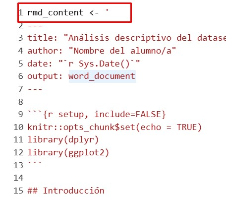

Captura de Google Colab

## Ejercicio 2.4: Descargar el informe generado

Así cada alumno/a se lleva su informe ya armado, con texto, código y gráficos integrados en un solo documento.

## Resumen Ejercicio 2

1. Abrir Colab → cambiar entorno de ejecución a **R**.
2. Instalar paquetes: `rmarkdown`, `dplyr`, `ggplot2`.
3. Escribir el contenido del `.Rmd` con `writeLines()`.
4. Ejecutar `rmarkdown::render("informe_iris.Rmd")`.
5. Descargar el `.word` desde el panel de Archivos.